# Exploratory Analysis Workflow

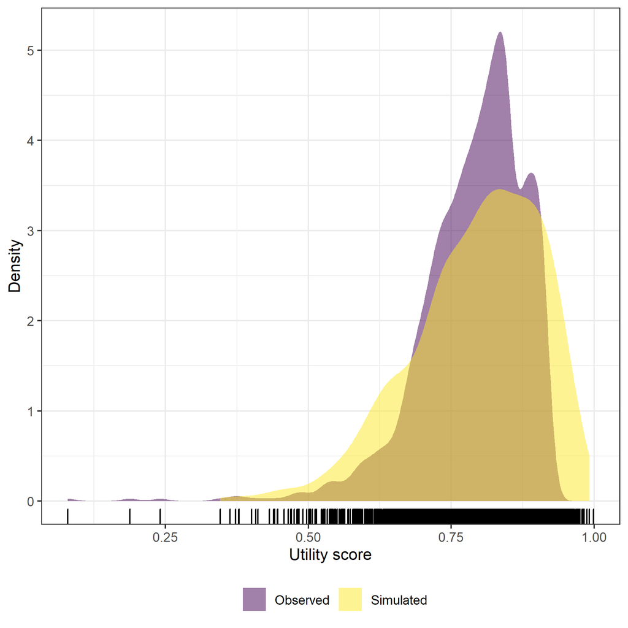

Plot 4

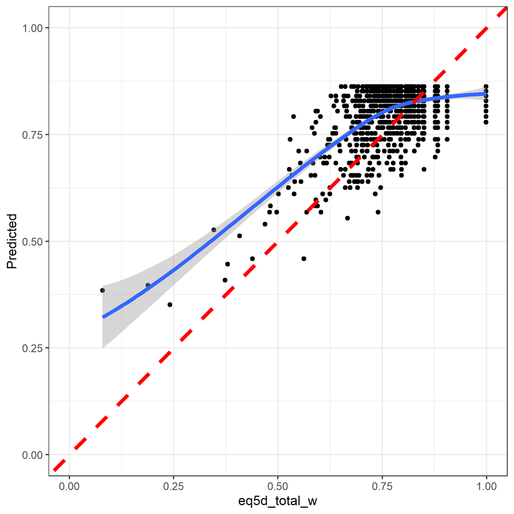

Plot 5

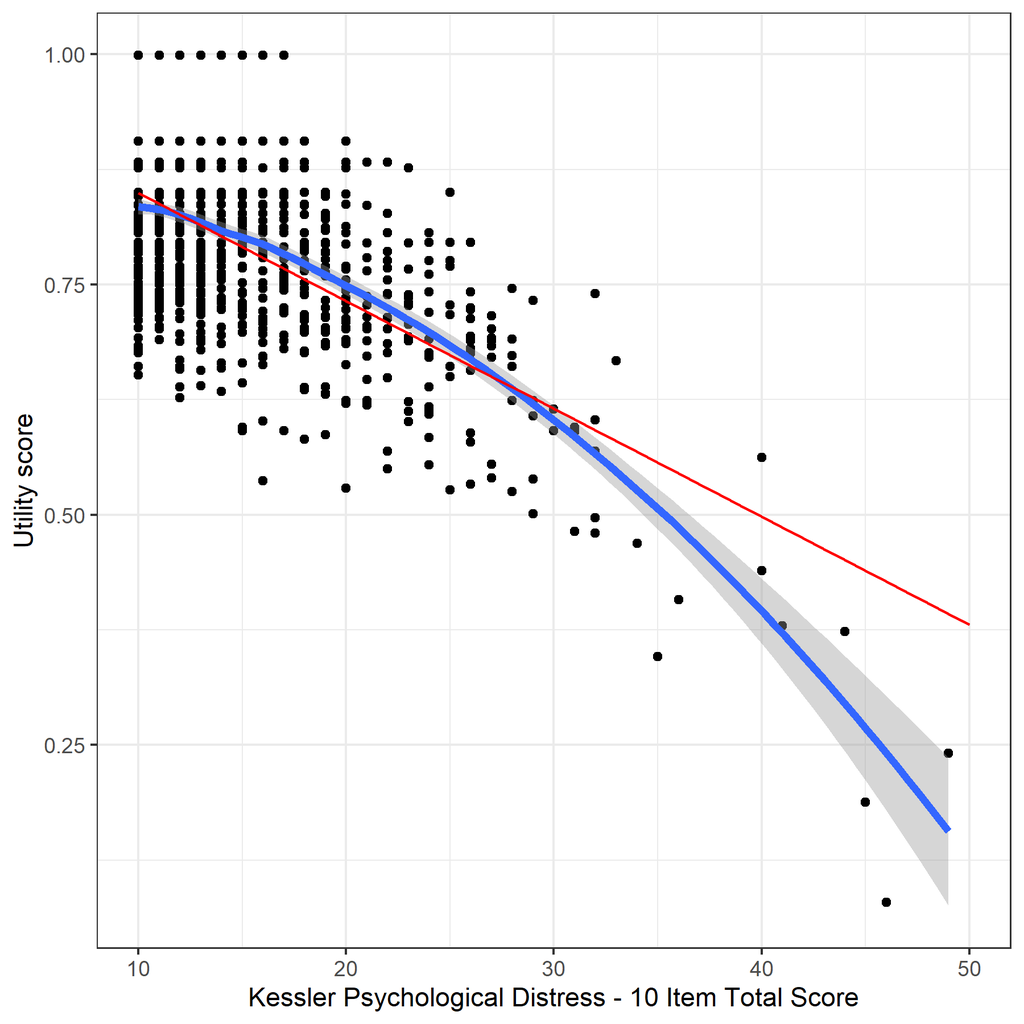

Plot 1

The `investigate` method also outputs a table summarising the performance of each of the candidate models.

```r
exhibit(x,
        mkdn_tbl_refs_chr = "tab:mdl_cmprsn",
        output_type_1L_chr = "HTML",
        what_1L_chr = "mdl_cmprsn",
        type_1L_chr = "results")
```

Comparison of candidate models using highest correlated predictor

| Model | Training model fit (averaged over 10 folds) Rsquared | Training model fit (averaged over 10 folds) RMSE | Training model fit (averaged over 10 folds) MAE | Testing model fit (averaged over 10 folds) RsquaredP | Testing model fit (averaged over 10 folds) RMSEP | Testing model fit (averaged over 10 folds) MAEP |
| --- | --- | --- | --- | --- | --- | --- |
| Ordinary Least Squares (no transformation) | 0.4079463 | 0.0762376 | 0.0599796 | 0.3911325 | 0.0761514 | 0.0600527 |
| Ordinary Least Squares (complementary log log transformation) | 0.3995892 | 0.0767730 | 0.0605442 | 0.3803300 | 0.0766537 | 0.0605794 |
| Generalised Linear Model with Gaussian distribution and log link | 0.3887797 | 0.0774636 | 0.0605710 | 0.3739220 | 0.0773766 | 0.0606410 |

We can now identify the highest performing model in each category of candidate model based on the testing R<sup>2</sup> statistic (RsquaredP in the previous table).

```r
procure(x,
        what_1L_chr = "prefd_mdls")
```

```
## [1] "OLS_NTF"
```

We can override these automated selections and instead incorporate other considerations (possibly based on judgments informed by visual inspection of the plots and the desirability of constraining predictions to a maximum value of one). We do this in the following command, specifying new preferred model types, in descending order of preference.

```r
# MAKE renew MTHD
#x@c_SpecificResults@a_SpecificShareable@shareable_outp_ls$mdl_smry_ls$prefd_mdl_types_chr <- c("OLS_NTF", "BET_CLL")
```

### Use most preferred model to compare all candidate predictors

```r
x <- investigate(x)
```

```r
# x@c_SpecificResults@a_SpecificShareable@shareable_outp_ls$mdl_smry_ls$predr_cmprsn_tb %>%
#     ready4show::print_table(output_type_1L_chr = "HTML",
#                           caption_1L_chr = "Comparison of all candidate predictors using preferred model")
```

```r
# x@c_SpecificResults@a_SpecificShareable@shareable_outp_ls$mdl_smry_ls$smry_of_mdl_sngl_predrs_tb %>%
#     ready4show::print_table(output_type_1L_chr = "HTML",
#                           caption_1L_chr = "Preferred single predictor model performance by candidate predictor")
```

```r
# x@c_SpecificResults@a_SpecificShareable@shareable_outp_ls$mdl_smry_ls$mdls_with_covars_smry_tb %>%
#     ready4show::print_table(output_type_1L_chr = "HTML",
#                             caption_1L_chr = "Performance of preferred models with covariate predictors by candidate predictor",
#                           use_lbls_as_col_nms_1L_lgl = T)
```

```r
# x@c_SpecificResults@a_SpecificShareable@shareable_outp_ls$mdl_smry_ls$signt_covars_chr
```

We can override the covariates to select, potentially because we want to select only covariates that are significant for all or most of the models. However, in the below example we have opted not to do so and continue to use no covariates as selected by the algorithm in the previous step.

```r
# x@c_SpecificResults@a_SpecificShareable@shareable_outp_ls$mdl_smry_ls$prefd_covars_chr <- c("COVARIATE WE WANT TO USE", "ANOTHER COVARIATE")
```

### Test preferred model with preferred covariates for each candidate predictor

We now conclude our model testing by rerunning the previous step, except confining our covariates to those we prefer.

```r
x <- investigate(x)
```

The previous call to the `write_mdls_with_covars_cmprsn` function saves the tested models along with the two plots for each model in the “E_Predrs_W_Covars_Sngl_Mdl_Cmprsn” sub-directory of “Output”.

## Apply preferred model types and predictors to longitudinal data

The next main step is to use the preferred model types and covariates identified from the preceding analysis of cross-sectional data in longitudinal analysis.

### Longitudinal mixed modelling

```r
y <- renewSlot(y,
             slot_nm_1L_chr = "iters_1L_int",
             new_val_xx = 4000L)
```

```r
y <- renewSlot(y,
             slot_nm_1L_chr = "control_ls",
             new_val_xx = list(adapt_delta = 0.99))
```

```r
y <- renewSlot(y,
               slot_nm_1L_chr = "depnt_var_min_max_dbl",
               new_val_xx = c(-1,1))
```

```r
x <- renewSlot(x,
               slot_nm_1L_chr = "b_SpecificParameters",
               y)
```

Next we create longitudinal and mixed versions of each of the models we specified in the previous step. Note, that in many cases both the `prior_ls` and `control_ls` arguments can be set to `NULL` (which may speed up execution). However, in this example doing so would result in warning messages suggesting a change to the adapt_delta control value (default = 0.8). We have therefore passed a value to the `control_ls` argument that addresses this issue.

```r
x<- investigate(x)
# x<-x_SpecificMixed
```

The `write_ts_mdls_from_alg_outp` function writes the models it tests to the “F_TS_Mdls” sub-directory of “Output” along with three plots for each model.

## Purge dataset copies

Because the files created in analysis are large, multiple objects containing copies of the source dataset have been saved to our output directory during the analysis process. We therefore need to delete all of these copies.

Purge write …

```r
## Author
author(x,
       type_1L_chr = "purge_write")
#outp_smry_ls$scored_data_tb <- NULL
```

## Share output

We can now publicly share our scored dataset and its associated metadata, using `Ready4useRepos` and its `share` method [as described in a vignette from the ready4use package](https://ready4-dev.github.io/ready4use/articles/V_01.html).

```r
z <- ready4use::Ready4useRepos(gh_repo_1L_chr = "ready4-dev/specific", # Replace with details of your repo.
                               gh_tag_1L_chr = "Documentation_0.0") # You must have write permissions.
# share
# "eq5d_ttu_SpecificMixed"

share(x,
      fl_nm_1L_chr = "eq5d_ttu_SpecificMixed",
      repos_Ready4useRepos = z)
```